# R workshop

https://github.com/CTrierMaansson/R_workshop_AUH

Christoffer Trier Maansson

Department of Clinical Biochemistry, Aarhus University Hospital, Denmark  
ctm@clin.au.dk

27 feb 2025

# 1 Quick note

Some of this may seem unnecessary to know, but understanding the environment you are working in, will help you when you face problems.

If you understand the code you use and avoid excessive copy pastes from ChatGPT without knowing how the code works, you will not end up as Ivan or Igor:

[figure not shown]

Fig 1. This is Ivan and Igor. Dont be like Ivan and Igor

# 2 R and R-studio

$$R \neq R_Studio$$

**R** is the coding language and the actual machinery performing the analyses.

Different versions of R can be installed in the same R-Studio

*When you publish, list the R version, not the Rstudio version*

**R-studio** is 99% of the times the interface you use when working in R. It is the most intuitive display of R code and outputs.

## 2.1 Suggested R-studio setup:

How you want to setup your R-studio is of course subjective but still I have some suggestions:

1. Always dark mode - It is just the prettier
2. Use three pane view - To add another pane go to View -> Panes -> Add source column (ctrl F7)
3. Separate work into *define*, *execute*, and *plots*
4. Only use R-markdown if you actually use its functions

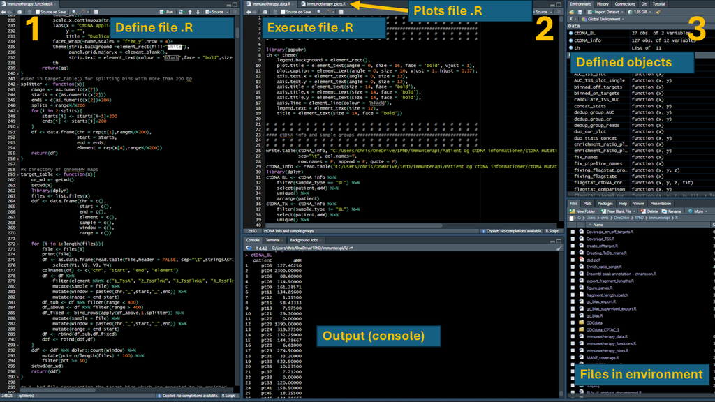

Fig 2. Suggested R-studio setup. 1, 2, and 3 indicates it is a three pane view in total consisting of 5 windows. For a project it is suggested to separate work into individual files, each with a specific role.

### 2.1.1 .R files in a project

It is **VERY** important to have a system when working in R. R analyses are not easy for anyone and having a structure helps you locate the definitions/variables/functions etc. you need. It is important to understand how you got to a specific result/plot and having a good system is the **ONLY** way to obtain this level of transparency

After some years I have found my system as illustrated in **Fig.2**:

My **define** file is where I have ALL my functions (discussed below) and nothing else. This means I can run the whole file and all my functions are defined and I can use these functions to explore my data.

My **execute** file is where I read data and modify/analyse/create the data. This is often done using the functions from the *define* file

My **plots** file is where I create the *ready to export* plots, meaning I do not perform any analysis in this file. I run functions from the *define* file on objects created in the *execute* file and save the plots in the correct locations.

## 2.2 Managing files

It is important to maintain good habit of organizing files and folders/directories. This includes the understanding of a `working directory`, meaning the folder where R looks for files/folders. If you have created an R project - The location of the project is the working directory.

Here are some **must** know functions regarding R environments and data management

| functions | description |
| --- | --- |
| getwd() | Get the path to working directory |
| setwd(‘<path>’) | Set the working directory as ‘<path>’ |
| paste0(‘<string_1>’,‘<string_2>’) | Combine character strings as <string_1string_2> |
| dir.create(<folder>) | Create a folder |
| file.create(<file>, overwrite = F) | Create a file without overwriting existing files |
| list.files(‘<path>’,include.dirs = T,full.names = T,recursive = T) | Get the full path of all files/folders in a folder and subdirectories |

### 2.2.1 Tasks for environment

Use the commands above or go to File -> New file etc. You can go to the Pathfinder(MS)/Finder(IOS) to create the directories

1. Create a folder called R_workshop
2. Create R_workshop/scripts/
3. Within R_workshop/scripts/ create three .R files: *workshop_functions.R, workshop_data.R, workshop_plots.R*
4. Create R_workshop/plots/
5. Create R_workshop/data_files/
6. Check that the correct files and folders have been created
7. Setup your R studio as shown in **Fig. 2**

**Solution:**

```r
#1
wd <- getwd()
dir.create("R_workshop")
#2
wd <- paste0(wd,"/R_workshop/")
setwd(wd)
dir.create("scripts")
#3
func_file <- "scripts/workshop_functions.R"
data_file <- "scripts/workshop_data.R"
plot_file <- "scripts/workshop_plots.R"
file.create(func_file)
file.create(data_file)
file.create(plot_file)
#4
dir.create("plots")
#5
dir.create("data_files")

#Test everything is correct
list.files(wd,include.dirs = T,full.names = T,recursive = T)
```

# 3 Functions

Creating functions is the only way to avoid mistakes and create consistent code and analyses. They enable code to reused but with modifications to e.g. input files, filter strategies, variables needed to analyzed, groupings etc.

The general structure of a function is:

```r
my_function <- function(argument){
    Code using argument
    return(results)
}
# And then the function is used with

my_function(argument)
```

Here argument can be any kind of R object.

Some key points when you use functions:

1. You can define default arguments inside `function()`:

```r
my_function <- function(argument = TRUE){
    if(argument){
        return("argument = TRUE")
    }
    else{
        return("argument = FALSE")
    }
}
my_function()
```

```
#> [1] "argument = TRUE"
```

```r
my_function(argument = TRUE)
```

```
#> [1] "argument = TRUE"
```

```r
my_function(argument = FALSE)
```

```
#> [1] "argument = FALSE"
```

2. You can create simple tests of the arguments:

```r
my_function <- function(argument = TRUE){
    if(!is.logical(argument)){
        stop("Invalid argument entry\n argument has to be a BOOLEAN/LOGICAL")
    }
    if(argument){
        return("argument = TRUE")
    }
    else{
        return("argument = FALSE")
    }
}
my_function()
```

```
#> [1] "argument = TRUE"
```

```r
my_function(argument = TRUE)
```

```
#> [1] "argument = TRUE"
```

```r
my_function(argument = "Horse")
```

```
#> Error in my_function(argument = "Horse"): Invalid argument entry
#>  argument has to be a BOOLEAN/LOGICAL
```

```r
my_function(argument = FALSE)
```

```
#> [1] "argument = FALSE"
```

3. You don’t have to return a variable

```r
my_function <- function(argument = TRUE){
  if(!is.logical(argument)){
    stop("Invalid argument entry\n argument has to be a BOOLEAN/LOGICAL")
  }
  if(argument){
    print("argument = TRUE")
  }
  else{
    print("argument = FALSE")
  }
}
```

4. functions don’t have to have arguments

```r
my_function <- function(){
    samples <- sample(10,3,replace = T)
    sample_sum <- sum(samples)
    if(sample_sum > 15){
        print("Sample sum is high")
    }else{
        print("Sample sum is low")
    }
    print("Sample sum is:")
    return(sample_sum)
}
set.seed(4)
my_function()
```

```
#> [1] "Sample sum is low"
#> [1] "Sample sum is:"
#> [1] 14
```

```r
set.seed(5)
my_function()
```

```
#> [1] "Sample sum is high"
#> [1] "Sample sum is:"
#> [1] 20
```

## 3.1 Task for functions

We now try to create some functions using the built-in data set `iris`. **Try to use the R-studio formatting we created above.**

Relevant functions for these task:

| functions | description |
| --- | --- |
| class(<object>) | Gives the type/class of any R object |
| str(<object>) | Give the basic structure (class, number of entries etc. in any R object) |
| list(‘<Entry_1>’ = result) | Create a named where the fist entry is named ‘Entry_1’ and contains result |
| paste0(‘<string_1>’,‘<string_2>’) | Combine character strings as <string_1string_2> |
| names(<list>) | Gives the names of a list |
| if(<test>){} | Procedes to what is within {} if test = TRUE |
| mean(<values>) | Calculates mean value |
| function() | Creates a function |
| stop(<message>) | Stops the function with an ERROR and sends the <message> |
| ! | Changes TRUE to FALSE and FALSE to TRUE |
| is.character(<value>) | Tests if <value> is a character string |
| is.numeric(<value>) | Tests if <value> is a numeric value |
| is.data.frame(<value>) | Tests if <value> is a data.frame |
| <vector_1> %in% <vector_2> | Tests which entries in vector_1 are also present in vector_2 |
| colnames(<data.frame>) | Gives the column names of the data.frame |

1. Make yourself comfortable with the data set `iris` with e.g. `class()` & `str()`

**Solution:**

```r
class(iris)
```

```
#> [1] "data.frame"
```

```r
str(iris)
```

```
#> 'data.frame':    150 obs. of  5 variables:
#>  $ Sepal.Length: num  5.1 4.9 4.7 4.6 5 5.4 4.6 5 4.4 4.9 ...
#>  $ Sepal.Width : num  3.5 3 3.2 3.1 3.6 3.9 3.4 3.4 2.9 3.1 ...
#>  $ Petal.Length: num  1.4 1.4 1.3 1.5 1.4 1.7 1.4 1.5 1.4 1.5 ...
#>  $ Petal.Width : num  0.2 0.2 0.2 0.2 0.2 0.4 0.3 0.2 0.2 0.1 ...
#>  $ Species     : Factor w/ 3 levels "setosa","versicolor",..: 1 1 1 1 1 1 1 1 1 1 ...
```

```r
class(iris$Sepal.Length)
```

```
#> [1] "numeric"
```

```r
class(iris[["Sepal.Length"]])
```

```
#> [1] "numeric"
```

2. Create a function `my_func_1()` with a single argument `data` which is set to `iris` as default

This function must be able to calculate the average values of `Sepal.Length` & `Sepal.Width` and return the values in a named `list`

*Hint: use len <- mean(data$Sepal.Length) and list(‘Sepal.Length_mean’ = len)*

**Solution:**

```r
my_func_1 <- function(data = iris){
    len_mean <- mean(data$Sepal.Length)
    wid_mean <- mean(data$Sepal.Width)
    res <- list("Sepal.Length_mean" = len_mean,
                "Sepal.Width_mean" = wid_mean)
    return(res)
}
my_func_1()
```

```
#> $Sepal.Length_mean
#> [1] 5.843333
#>
#> $Sepal.Width_mean
#> [1] 3.057333
```

3. Recreate `my_func_1()` as `my_func_2()`, now with two arguments (`data` & `variable`)

`variable` is a column name existing in `iris`. Use `variable` to extract values from `iris` and calculate the average. The function should still return a named list with the average value

*Hint: use values <- data[[variable]], label <- paste0(variable,“_mean”)*,* and names(list()) <- label*

**Solution:**

```r
my_func_2 <- function(data = iris,variable){
    avg <- mean(data[[variable]])
    label = paste0(variable,"_mean")
    res <- list(avg)
    names(res) <- label
    return(res)
}
my_func_2(data = iris, variable = "Sepal.Width")
```

```
#> $Sepal.Width_mean
#> [1] 3.057333
```

4. Recreate `my_func_2()` as `my_func_3()`, but make **tests** that ensures `variable` is the correct class **and** the data extracted from `variable` can be used to calculate an average (meaning `variable` contains `numeric` values)

If these requirements are not met the function should give an error (`stop()`) The function should still return a named list with the average value

*Hint: use* `if(!is.numeric()){stop()}` and `if(!is.character()){stop()}`

**Solution:**

```r
my_func_3 <- function(data = iris,variable){
    if(!is.character(variable)){
        stop("variable has to be a character")
    }
    values <- data[[variable]]
    if(!is.numeric(values)){
        stop(paste0("Values in the variable:\n",
                    variable,"\n",
                    "are not numeric. Select another variable"))
    }
    avg <- mean(values)
    label = paste0(variable,"_mean")
    res <- list(avg)
    names(res) <- label
    return(res)
}
my_func_3(variable = "Sepal.Width")
```

```
#> $Sepal.Width_mean
#> [1] 3.057333
```

5. Recreate `my_func_3()` as `my_func_4()`, where `data` can be other data sets than `iris` e.g `Puromycin` and make sure `variable` only can contain variable names present in the data set used as `data`

The function should still return a named list with the average value

*Hint: use vars <- colnames(data) and if(!(variable %in% vars)){stop()}*

**Solution:**

```r
my_func_4 <- function(data = iris,variable){
    if(!is.character(variable)){
        stop("variable has to be a character")
    }
    if(!is.data.frame(data)){
        stop("data has to be a data.frame")
    }
    vars <- colnames(data)
    if(!(variable %in% vars)){
        stop(paste0("The variable:\n",
                    variable,"\n",
                    "does not exist in the data set. Select another variable name"))
    }
    values <- data[[variable]]
    if(!is.numeric(values)){
        stop(paste0("Values in the variable:\n",
                    variable,"\n",
                    "are not numeric. Select another variable"))
    }
    avg <- mean(values)
    label = paste0(variable,"_mean")
    res <- list(avg)
    names(res) <- label
    return(res)
}
my_func_4(variable = "Sepal.Width")
```

```
#> $Sepal.Width_mean
#> [1] 3.057333
```

```r
my_func_4(data = Puromycin, variable = "rate")
```

```
#> $rate_mean
#> [1] 126.8261
```

# 4 `tidy`

`tidy` is a “language” within R which is outside of `base` R. It much more powerful, fast, and intuitive than `base` R. I recommend ALWAYS using `tidy` to perform basic table manipulation, plotting etc. Most `tidy` packages can be loaded with `library(tidyverse)`, however I recommend loading individual `tidy` packages. The most frequently used include:

1. `dplyr`
2. `ggplot2`
3. `ggpubr`
4. `tidyr`

So now run:

```r
# If you DONT have the packages installed run:
install.packages("dplyr")
install.packages("ggplot2")
install.packages("ggpubr")
install.packages("tidyr")

#Then the packages can be loaded
library(dplyr)
library(ggplot2)
library(ggpubr)
library(tidyr)
```

## 4.1 Most relevant `tidy` functions

Here I present some of the most relevant `tidy` functions. We will use these in later tasks

### 4.1.1 `%>%`

This is called a pipe and it takes a `data.frame` on the left side and *pushes* the data into a function on the right side. **Good coding practice includes going to a new line after each `%>%`**

### 4.1.2 `filter()`

This is used to filter a data set based on entries in a specific variable:

```r
iris %>%
    filter(Species == "virginica") %>%
    head() # Just to show top 5 rows
```

```
#>   Sepal.Length Sepal.Width Petal.Length Petal.Width   Species
#> 1          6.3         3.3          6.0         2.5 virginica
#> 2          5.8         2.7          5.1         1.9 virginica
#> 3          7.1         3.0          5.9         2.1 virginica
#> 4          6.3         2.9          5.6         1.8 virginica
#> 5          6.5         3.0          5.8         2.2 virginica
#> 6          7.6         3.0          6.6         2.1 virginica
```

```r
iris %>%
    filter(Petal.Length >= 2) %>%
    head() # Just to show top 5 rows
```

```
#>   Sepal.Length Sepal.Width Petal.Length Petal.Width    Species
#> 1          7.0         3.2          4.7         1.4 versicolor
#> 2          6.4         3.2          4.5         1.5 versicolor
#> 3          6.9         3.1          4.9         1.5 versicolor
#> 4          5.5         2.3          4.0         1.3 versicolor
#> 5          6.5         2.8          4.6         1.5 versicolor
#> 6          5.7         2.8          4.5         1.3 versicolor
```

Usually you would use `filter()` with a variable name and then some kind of logic test

### 4.1.3 `mutate()`

This is used to create a new column in the data set

```r
iris %>%
    mutate(Petal.Classification = ifelse(Petal.Length >= 2,
                                         "long",
                                         "short"),
           .before = "Species") %>%
    slice(1,2,3,140,141) # Just to show specific rows
```

```
#>   Sepal.Length Sepal.Width Petal.Length Petal.Width Petal.Classification
#> 1          5.1         3.5          1.4         0.2                short
#> 2          4.9         3.0          1.4         0.2                short
#> 3          4.7         3.2          1.3         0.2                short
#> 4          6.9         3.1          5.4         2.1                 long
#> 5          6.7         3.1          5.6         2.4                 long
#>     Species
#> 1    setosa
#> 2    setosa
#> 3    setosa
#> 4 virginica
#> 5 virginica
```

```r
iris %>%
    mutate(Petal.Area = Petal.Length * Petal.Width,
           .before = "Species") %>%
    slice(1,2,3,140,141) # Just to show specific rows
```

```
#>   Sepal.Length Sepal.Width Petal.Length Petal.Width Petal.Area   Species
#> 1          5.1         3.5          1.4         0.2       0.28    setosa
#> 2          4.9         3.0          1.4         0.2       0.28    setosa
#> 3          4.7         3.2          1.3         0.2       0.26    setosa
#> 4          6.9         3.1          5.4         2.1      11.34 virginica
#> 5          6.7         3.1          5.6         2.4      13.44 virginica
```

Using `.before`, `.after` you can select where in the data the new column is inserted

### 4.1.4 `select()`

This is used to select variables from the data set.

```r
iris %>%
    select(Petal.Length,Petal.Width) %>%
    head() # Just to show top 5 rows
```

```
#>   Petal.Length Petal.Width
#> 1          1.4         0.2
#> 2          1.4         0.2
#> 3          1.3         0.2
#> 4          1.5         0.2
#> 5          1.4         0.2
#> 6          1.7         0.4
```

```r
iris %>%
    select(starts_with("Petal")) %>%
    head() # Just to show top 5 rows
```

```
#>   Petal.Length Petal.Width
#> 1          1.4         0.2
#> 2          1.4         0.2
#> 3          1.3         0.2
#> 4          1.5         0.2
#> 5          1.4         0.2
#> 6          1.7         0.4
```

```r
iris %>%
    select(contains("Width")) %>%
    head() # Just to show top 5 rows
```

```
#>   Sepal.Width Petal.Width
#> 1         3.5         0.2
#> 2         3.0         0.2
#> 3         3.2         0.2
#> 4         3.1         0.2
#> 5         3.6         0.2
#> 6         3.9         0.4
```

```r
iris %>%
    select(-Species) %>%
    head() # Just to show top 5 rows
```

```
#>   Sepal.Length Sepal.Width Petal.Length Petal.Width
#> 1          5.1         3.5          1.4         0.2
#> 2          4.9         3.0          1.4         0.2
#> 3          4.7         3.2          1.3         0.2
#> 4          4.6         3.1          1.5         0.2
#> 5          5.0         3.6          1.4         0.2
#> 6          5.4         3.9          1.7         0.4
```

Build in functions e.g. `last_col()` `starts_with()`, `contains()` can be used to select specific columns. You can select all columns except one (or several) columns with `-`

### 4.1.5 `arrange()`

This is used to sort a data set based on one or several columns:

```r
iris %>%
    arrange(Petal.Length) %>%
    head() # Just to show top 5 rows
```

```
#>   Sepal.Length Sepal.Width Petal.Length Petal.Width Species
#> 1          4.6         3.6          1.0         0.2  setosa
#> 2          4.3         3.0          1.1         0.1  setosa
#> 3          5.8         4.0          1.2         0.2  setosa
#> 4          5.0         3.2          1.2         0.2  setosa
#> 5          4.7         3.2          1.3         0.2  setosa
#> 6          5.4         3.9          1.3         0.4  setosa
```

```r
iris %>%
    arrange(desc(Petal.Length)) %>%
    head() # Just to show top 5 rows
```

```
#>   Sepal.Length Sepal.Width Petal.Length Petal.Width   Species
#> 1          7.7         2.6          6.9         2.3 virginica
#> 2          7.7         3.8          6.7         2.2 virginica
#> 3          7.7         2.8          6.7         2.0 virginica
#> 4          7.6         3.0          6.6         2.1 virginica
#> 5          7.9         3.8          6.4         2.0 virginica
#> 6          7.3         2.9          6.3         1.8 virginica
```

```r
iris %>%
    arrange(Sepal.Length,Petal.Length) %>%
    head(n = 10) # Just to show top 10 rows
```

```
#>    Sepal.Length Sepal.Width Petal.Length Petal.Width Species
#> 1           4.3         3.0          1.1         0.1  setosa
#> 2           4.4         3.0          1.3         0.2  setosa
#> 3           4.4         3.2          1.3         0.2  setosa
#> 4           4.4         2.9          1.4         0.2  setosa
#> 5           4.5         2.3          1.3         0.3  setosa
#> 6           4.6         3.6          1.0         0.2  setosa
#> 7           4.6         3.4          1.4         0.3  setosa
#> 8           4.6         3.2          1.4         0.2  setosa
#> 9           4.6         3.1          1.5         0.2  setosa
#> 10          4.7         3.2          1.3         0.2  setosa
```

`desc()` is used to reverse a given sort order

### 4.1.6 `count()`

This is used to count entries based on a given variable

```r
iris %>%
    count(Species)
```

```
#>      Species  n
#> 1     setosa 50
#> 2 versicolor 50
#> 3  virginica 50
```

```r
iris %>%
    count(Petal.Length >= 2)
```

```
#>   Petal.Length >= 2   n
#> 1             FALSE  50
#> 2              TRUE 100
```

Can be used count the number of a given entry (similar to `table()`). Can also be used to count the number of entries following a logical test. Works really well in combination with `group_by()` (see below)

### 4.1.7 `group_by()` and `summerise()`/`summarize()`/`reframe()`

Is used to group the data set based on a single or **multiple** variables. The *grouped* data set can then be used as input in several functions

```r
iris %>%
    group_by(Species) %>%
    count() %>%
    ungroup()
```

```
#> # A tibble: 3 × 2
#>   Species        n
#>   <fct>      <int>
#> 1 setosa        50
#> 2 versicolor    50
#> 3 virginica     50
```

```r
iris %>%
    group_by(Species) %>%
    summarise(Petal.Length_mean = mean(Petal.Length),
              Petal.Length_sd = sd(Petal.Length))
```

```
#> # A tibble: 3 × 3
#>   Species    Petal.Length_mean Petal.Length_sd
#>   <fct>                  <dbl>           <dbl>
#> 1 setosa                  1.46           0.174
#> 2 versicolor              4.26           0.470
#> 3 virginica               5.55           0.552
```

```r
iris %>%
    group_by(Species) %>%
    reframe(Petal.Length = Petal.Length,
            Petal.Length_mean = mean(Petal.Length),
            Petal.Length_sd = sd(Petal.Length)) %>%
    slice(1,2,3,140,141) # Just to show specific rows
```

```
#> # A tibble: 5 × 4
#>   Species   Petal.Length Petal.Length_mean Petal.Length_sd
#>   <fct>            <dbl>             <dbl>           <dbl>
#> 1 setosa             1.4              1.46           0.174
#> 2 setosa             1.4              1.46           0.174
#> 3 setosa             1.3              1.46           0.174
#> 4 virginica          5.4              5.55           0.552
#> 5 virginica          5.6              5.55           0.552
```

In order to avoid mistakes it is a good idea to include `ungroup()` after you are done with group manipulations.

`group_by()` works extremely well with `summerise()`/`summarize()` or `reframe()`.

It can be hard to differentiate between `summarize()` and `reframe()`. But think of it as `summarize()` gives a small data set but if you want all original entries then use `reframe()`.

### 4.1.8 `join()`

Several join functions exist. They are used to combine `data.frames` based on common entries, where the column name typically is identical. I think the following picture very intuitively illustrates the differences between each type of `join` function.

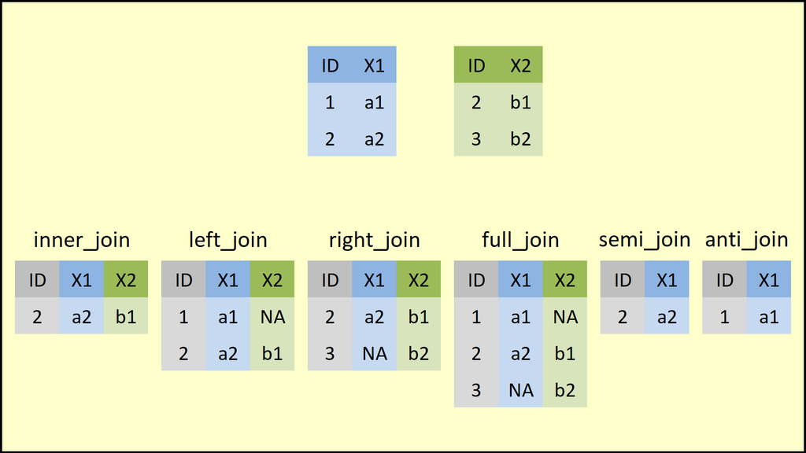

Fig 3. How different join functions are used to combine data.frames

Here are some examples of how the to use the functions *These datasets are unrelated so this specific join is useless*:

```r
df_1 <- as.data.frame(Indometh) %>%
    slice(1,12,45) %>% #selecting a few examples
    mutate(Subject = as.character(Subject)) # recreating class
df_1
```

```
#>   Subject time conc
#> 1       1 0.25 1.50
#> 2       2 0.25 2.03
#> 3       5 0.25 2.05
```

```r
df_2 <- as.data.frame(Orange) %>%
    slice(1,10,18) %>%  #selecting a few examples
    mutate(Tree = as.character(Tree))# recreating class
colnames(df_2)[1] <- "Subject" # making sure the relevant variable has the correct name
df_2
```

```
#>   Subject  age circumference
#> 1       1  118            30
#> 2       2  664           111
#> 3       3 1004           108
```

```r
df_left <- df_1 %>%
    left_join(df_2,by ="Subject")
df_left
```

```
#>   Subject time conc age circumference
#> 1       1 0.25 1.50 118            30
#> 2       2 0.25 2.03 664           111
#> 3       5 0.25 2.05  NA            NA
```

```r
df_right <- df_1 %>%
    right_join(df_2,by ="Subject")
df_right
```

```
#>   Subject time conc  age circumference
#> 1       1 0.25 1.50  118            30
#> 2       2 0.25 2.03  664           111
#> 3       3   NA   NA 1004           108
```

```r
df_full <- df_1 %>%
    full_join(df_2,by ="Subject")
df_full
```

```
#>   Subject time conc  age circumference
#> 1       1 0.25 1.50  118            30
#> 2       2 0.25 2.03  664           111
#> 3       5 0.25 2.05   NA            NA
#> 4       3   NA   NA 1004           108
```

```r
df_inner <- df_1 %>%
    inner_join(df_2,by ="Subject")
df_inner
```

```
#>   Subject time conc age circumference
#> 1       1 0.25 1.50 118            30
#> 2       2 0.25 2.03 664           111
```

## 4.2 `tidy` tasks

Use the introduced functions above to complete the following tasks. **Again remember to use the file formatting introduced above**

Additional helpful functions:

| functions | description |
| --- | --- |
| ifelse(<test>,<if TRUE>,<if FALSE>) | Returns two different outputs dependent on whether the test is TRUE or FALSE |
| sum(<values>) | Sums the values in <values> |
| <vector_1> %in% <vector_2> | Tests which entries in vector_1 are also present in vector_2 |

1. Create a function `tidy_func_1()` which takes the iris data set as default `data` argument and classifies observations as “long” (Petal.Length >=5) or “short” (Petal.Length < 5). The resulting `data.frame` must be exported and saved as `iris_mod`

*Hint: use mutate()*

**Solution:**

```r
tidy_func_1 <- function(data = iris){
    df <- data %>%
        mutate(Petal.Length_class = ifelse(Petal.Length >= 5,
                                           "long","short"))
    return(df)
}

iris_mod <- tidy_func_1()
```

2. Create a function `tidy_func_2()` which takes the output of `tidy_func_1()` as a default argument and count the number of “long” and “short” entries for each `Species` *HINT: use two variable names in group_by()*. The resulting ungrouped `data.frame` must be exported and saved as `iris_groups`

**Solution:**

```r
tidy_func_2 <- function(data = iris_mod){
    df <- data %>%
        group_by(Species,Petal.Length_class) %>%
        count() %>%
        ungroup()
    return(df)
}
iris_groups <- tidy_func_2()
```

3. Create a function `tidy_func_3()` which takes the output of `tidy_func_2()` as a default argument and add a column with the percent of “long” and “short” petals for each species and export the `data.frame` as `iris_group_freq` *HINT: use group_by() and reframe()*

**Solution:**

```r
tidy_func_3 <- function(data = iris_groups){
    df <- data %>%
        group_by(Species) %>%
        reframe(Petal.Length_class = Petal.Length_class,
                n = n,
                percent = n/sum(n)*100) %>%
        ungroup()
    return(df)
}
iris_group_freq <- tidy_func_3()
```

Now we move to another data set, `mtcars`. Copy the following `data.frame` into `workshop_data.R` and execute

```r
mtcars_types <- data.frame(car = c("Mazda RX4",
                                   "Mazda RX4 Wag",
                                   "Datsun 710",
                                   "Merc 240D",
                                   "Merc 230",
                                   "Merc 280",
                                   "Merc 280C",
                                   "Merc 450SE",
                                   "Merc 450SL",
                                   "Merc 450SLC",
                                   "Toyota Corolla",
                                   "Toyota Corona",
                                   "Hornet Sportabout",
                                   "Hornet 4 Drive",
                                   "Valiant",
                                   "Duster 360",
                                   "Cadillac Fleetwood",
                                   "Lincoln Continental",
                                   "Fiat 128"),
                           manufacturer = c("Mazda",
                                            "Mazda",
                                            "Nissan",
                                            rep("Mercedes",7),
                                            "Toyota",
                                            "Toyota",
                                            "AMC",
                                            "AMC",
                                            rep("Other",5)))
```

And run the following commands to create `mtcars_mod` from the built-in `mtcars`:

```r
mtcars_mod <- mtcars
mtcars_mod$car <- rownames(mtcars)
rownames(mtcars_mod) <- NULL
```

4. Create a function `tidy_func_4()` which takes `mtcars_mod` as a default argument. Remove the variables `vs`,`disp`,`drat`,`wt` and `am`. Then filter cars also present in `mtcars_types` and add the column with the corresponding manufacturer. *HINT: use one of the `join` functions to combine the data.frames*. Then sort the data set according to `mpg` with the highest value as the first row. Save the resulting `data.frame` as `mtcars_mod_sele`

**Solution:**

```r
tidy_func_4 <- function(data = mtcars_mod){
    df <- data %>%
        select(-c(vs,am,disp,drat,wt)) %>%
        filter(car %in% mtcars_types$car) %>%
        left_join(mtcars_types, by = "car") %>%
        arrange(desc(mpg))
    return(df)
}
mtcars_mod_sele <- tidy_func_4()
```

# 5 Saving data

It can often be relevant to save your `data.frames` to save time. Sometimes you perform extensive analyses, where the output can be relatively simple. By saving the data you do not have to re-analyze the data and you can move quickly to stats, plots, etc.

## 5.1 Saving as `.txt`

I recommend saving `data.frames` as `.txt` files because it is the most simple format (smallest file size). `.txt` files can also be opened in any normal text editor and can serve as input files for other programs. Alternatively you can save as `.csv` or even `.xlsx` so the readout can be opened in excel.

## 5.2 Saving as `.rds`

R also has its own file type for objects, which is called `RDS`. This format is super useful when you need to save other R objects than: `data.frame`, `tibble`, or `data.table`. This could include `lists`, `vectors`, and even `plots`.

## 5.3 Saving data task

Helpful functions for saving:

| functions | description |
| --- | --- |
| saveRDS(<object>, <path>) | Save an object in the designated path, finish the path with <file_name>.rds |
| readRDS(<path>) | Import a .rds object back into R from the path |
| write.table(<object>, <path>) | Save a table in the designated path, finish the path with <file_name>.txt |
| read.table(<path>, header = TRUE) | Import a table back into R from the path as a data.frame |

1. in `workshop_data.R` save `mtcars_mod_sele` as `mtcars_mod_sele.txt` in the `R_workshop/data_files/` directory and write code to reload the data set. *HINT: I always suggest to write the FULL PATH when saving and reloading.* *Use `getwd()` to get the full path to your current directory*

**Solution**

```r
write.table(mtcars_mod_sele,
            "C:/Users/chris/OneDrive/1PhD/R_workshop_AUH/R_workshop/data_files/mtcars_mod_sele.txt",
            sep = "\t")

mtcars_mod_sele <- read.table("C:/Users/chris/OneDrive/1PhD/R_workshop_AUH/R_workshop/data_files/mtcars_mod_sele.txt",
                              header = TRUE,
                              sep = "\t")
```

# 6 Plots

Plots are the main reason to use R. It is **extremely** flexible and you can essentially make any plot you want.

From the relatively simple boxplots:

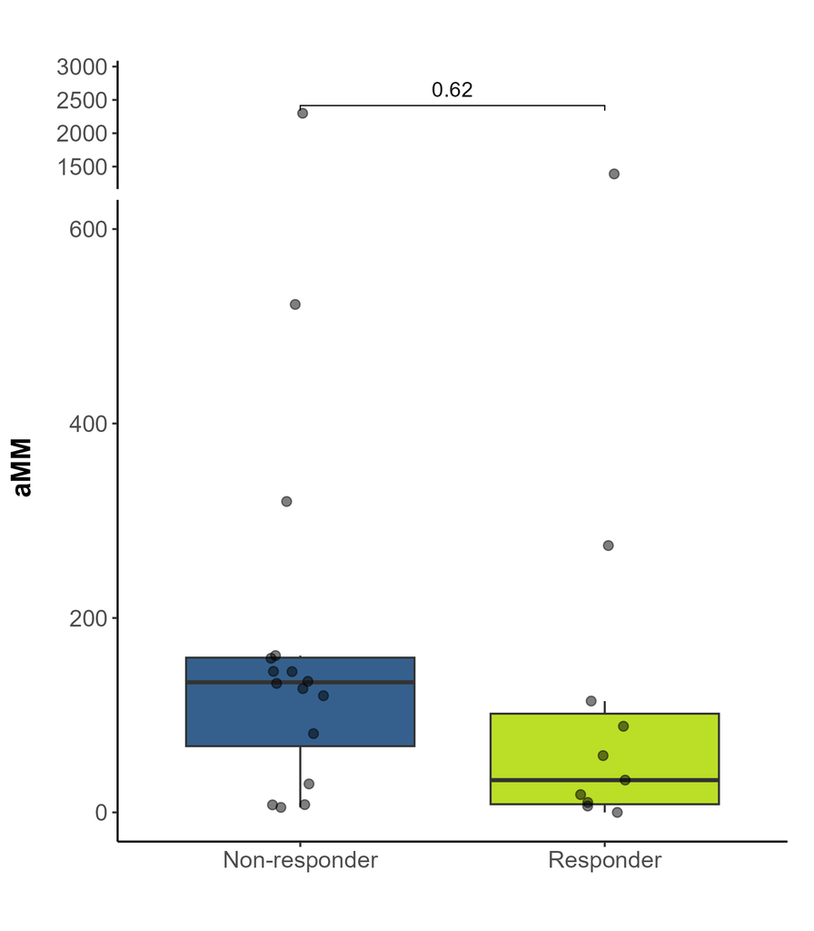

Fig 4. Boxplot example

To the more complex plot types without specific names:

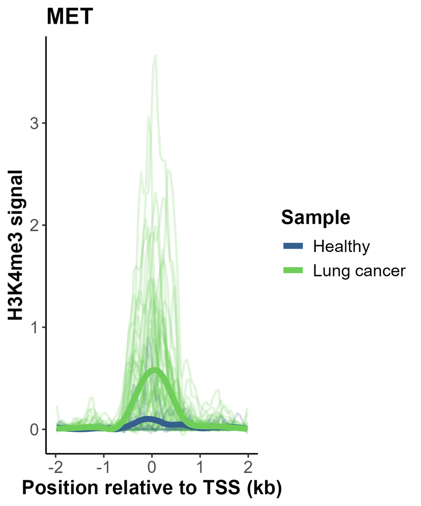

Fig 5. Enrichment track

and the complete figures:

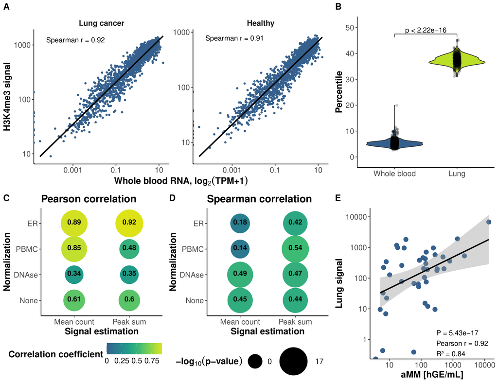

Fig 6. Complete figure

**All of this is made using `tidy` packages**

But it is simply impossible for me to explain everything in this workshop.

## 6.1 `ggplot2`

Similar to `tidy` the `ggplot2` world is a specific language within R. It follows a very specific structure and works together with the `tidy` format

The basic structure of a `ggplot` is:

```r
df #data.frame with the data

ggplot(data = df, aes(x = var1, y = var2))+ #Define what from the data is used
    geom_xyz()+ # A specific type of data is plotted
    geom_qwe()+ # Another type of data is plotted
    theme()+ #the colors, font sizes, etc. are modified
    labs()+  #the labels are added
    scale_prq() #The scales of the axes, colors, point sizes etc. are modified
```

*Notice that in stead of `%>%` we use `+`*

**Therefore please go to new line after each `+`**

### 6.1.1 `aes`

It is important to understand what goes inside `aes()`:

`aes` stands for aesthetics which encompass what variables from the data set can affect how the plot looks like in the end.

`aes` parameters include (but are not limited to):

1. x - what is plotted on the first axis
2. y - what is plotted on the second axis
3. fill - What determines the “fill” color of etc. bars and boxes
4. color - what determines the “color” of lines and points
5. size - what determines the size of lines, points etc.
6. group - what determines how the data should be grouped
7. shape - what determines the shape of lines, points etc.
8. label - where does the labels come from

It is important to understand that `aes()` can be used inside `ggplot()` which means this variable e.g. determines the color for all `geoms`. Like this:

```r
df #data.frame with the data

ggplot(data = df, aes(x = var1, y = var2,# data from var1 and var2 is plotted
                      color = var3))+ # and var3 determines color
    geom_point()+
    geom_line()
```

But `aes` can also be included in the different `geom()` functions. This is smart because then two separate variables can determine the color of e.g. lines and points. Like this:

```r
df #data.frame with the data

ggplot(data = df, aes(x = var1, y = var2))+ # data from var1 and var2 is plotted
    geom_point(aes(color = var3))+ # points colored based on var3
    geom_line(aes(color = var4)) # lines colored based on var4
```

### 6.1.2 `geom`

`geoms` are ways to tell `ggplot` what type of plot you want.

`geom` functions include (but are not limited to):

1. geom_point - basic points
2. geom_bar - bar graph
3. geom_line - basic lines
4. geom_boxplot - basic boxplot
5. geom_jitter - points randomly jittered
6. geom_text - text labels
7. geom_smooth - Smooth regression line based on data
8. geom_ribbon - Colored area between axis and line
9. geom_vline or geom_hline - vertical or horizontal lines
10. geom_violin - basic violin plots
11. geom_tile - Sqaures used for heatmaps

Here a few examples of how `geoms` can be used:

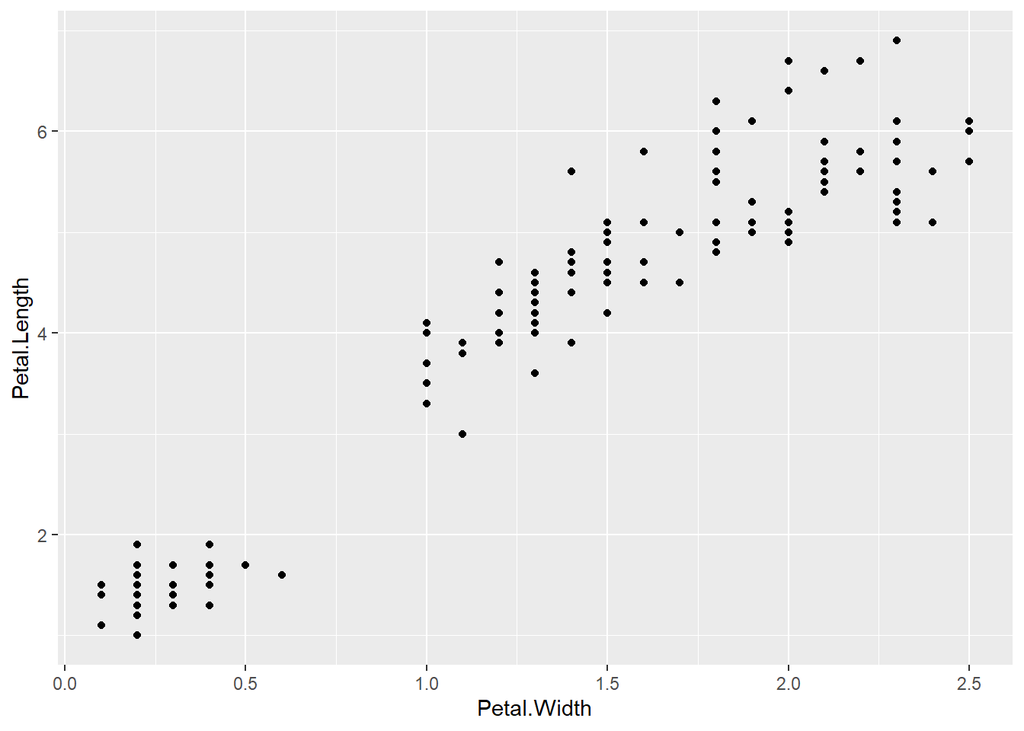

```r
ggplot(iris,aes(x = Petal.Width,y = Petal.Length))+
    geom_point()
```

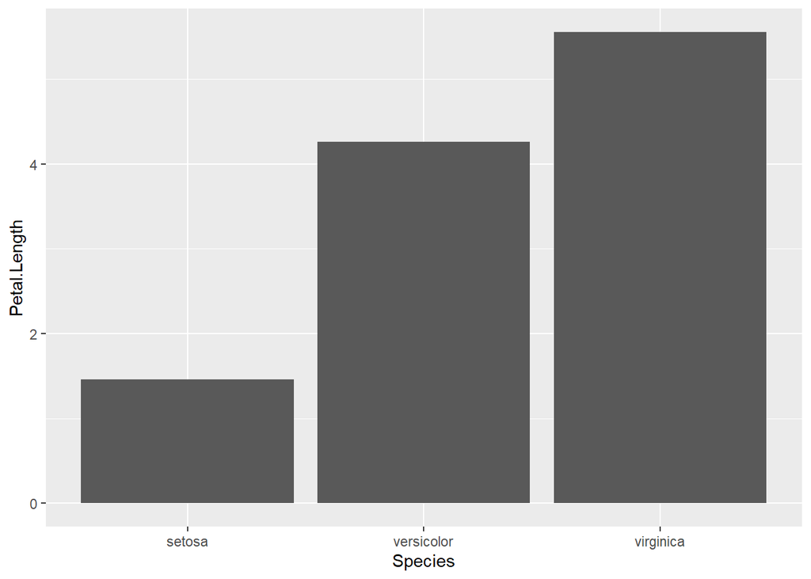

```r
ggplot(iris,aes(x = Species,y=Petal.Length))+
    geom_bar(stat = "summary")
```

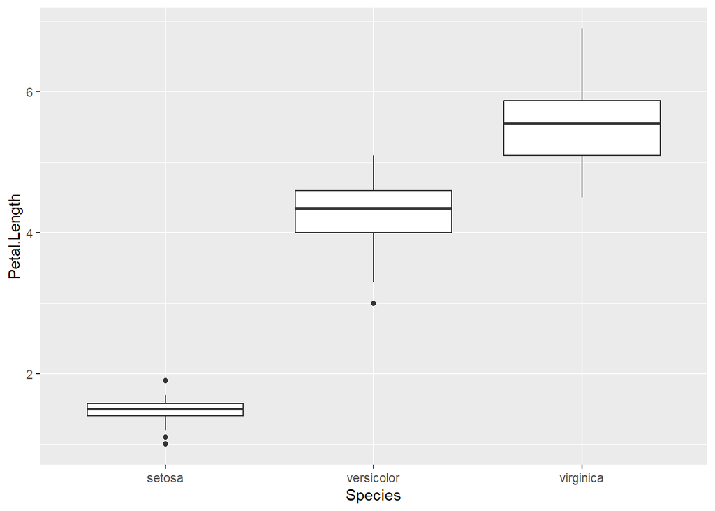

```r
ggplot(iris,aes(x = Species,y=Petal.Length))+
    geom_boxplot()
```

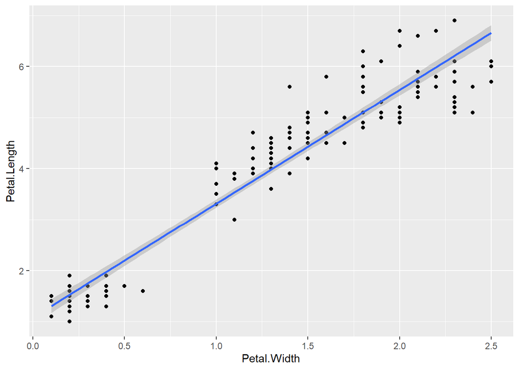

```r
ggplot(iris,aes(x = Petal.Width,y = Petal.Length))+
    geom_point()+
    geom_smooth(method = "lm")
```

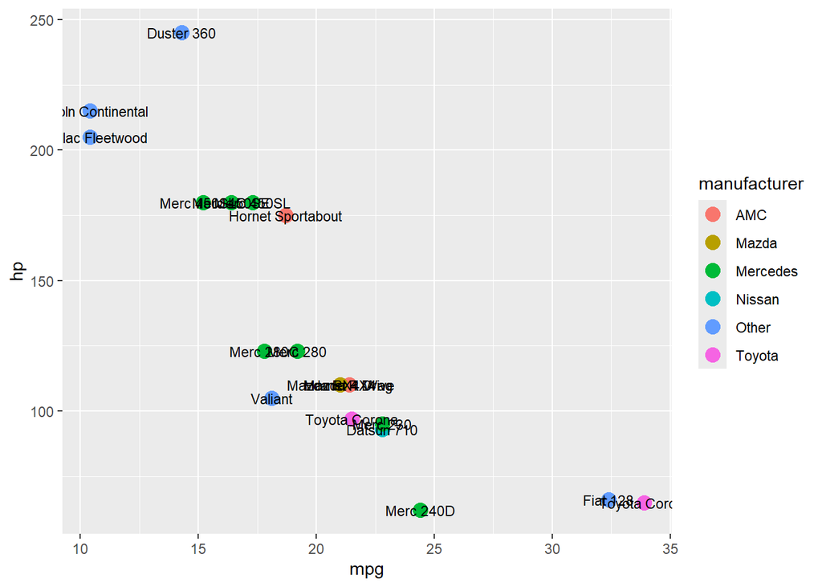

```r
ggplot(mtcars_mod_sele, aes(x=mpg,y=hp))+
    geom_point(aes(color = manufacturer),
               size = 4)+
    geom_text(aes(label = car),size = 3)
```

### 6.1.3 `viridis`, `theme()` and general layout

**I think the default colors in R ugly.** I therefore almost always use the color pallets in the `viridis` package. They similar to default R colors, but just nicer.

Therefore run:

```r
# If you DONT have the package installed run:
install.packages("viridis")

#Then the packages can be loaded
library(viridis)
```

`theme()` is a function to customize the layout of your plot such as font sizes, angles, font types etc. To generalize things for a project I add the same theme function to **ALL** plots such as:

```r
#Define theme:
th <- theme(
        legend.background = element_rect(),
        plot.title = element_text(angle = 0, size = 16, face = 'bold', vjust = 1),
        plot.caption = element_text(angle = 0, size = 10, vjust = 1, hjust = 0.37),
        axis.text.x = element_text(angle = 0, size = 12),
        axis.text.y = element_text(angle = 0, size = 12),
        axis.title = element_text(size = 14, face = 'bold'),
        axis.title.x = element_text(size = 14, face = 'bold'),
        axis.title.y = element_text(size = 14, face = 'bold'),
        axis.line = element_line(colour = 'black'),
        legend.text = element_text(size = 12),
        title = element_text(size = 14, face = "bold"))

df #data.frame with the data

ggplot(data = df, aes(x = var1, y = var2))+
    geom_point()+
    th
```

All `ggplot` also have layout themes.

**NEVER USE THE DEFAULT GGPLOT THEME (theme_grey())!!! IT SCREAMS INEXPERIENCE!**

I suggest adding `theme_bw()`, `theme_classic()`, or `theme_minimal`:

**`theme_grey()` (default)**

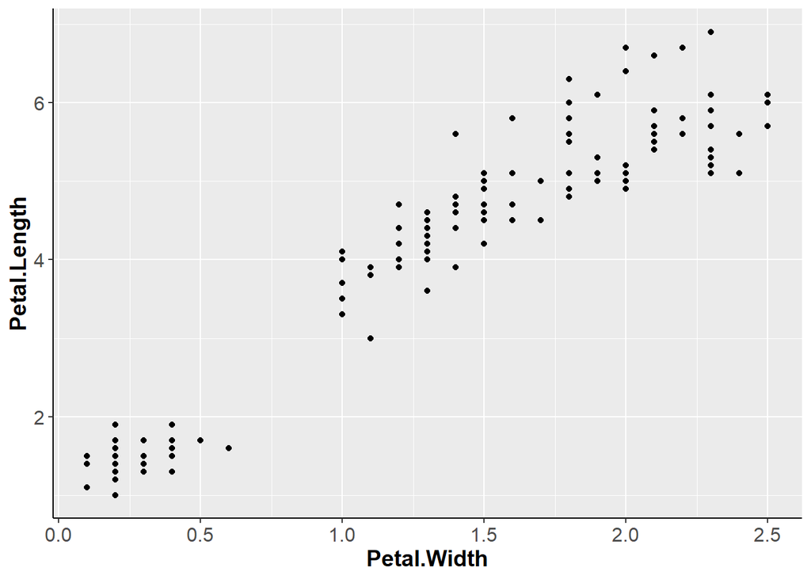

**`theme_bw()`**

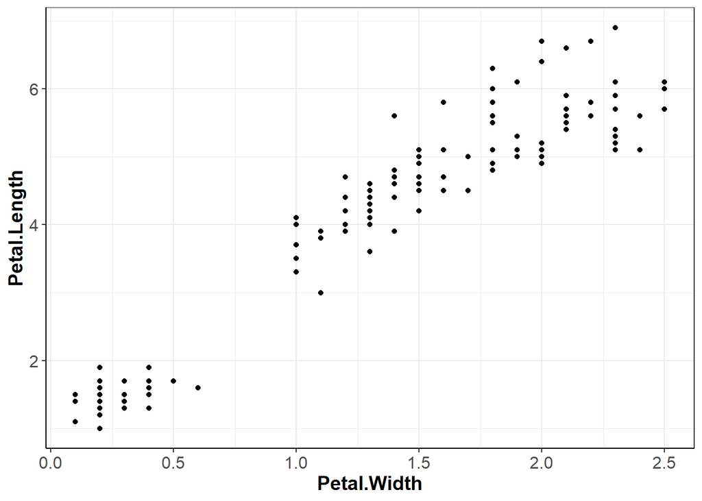

**`theme_classic()`**

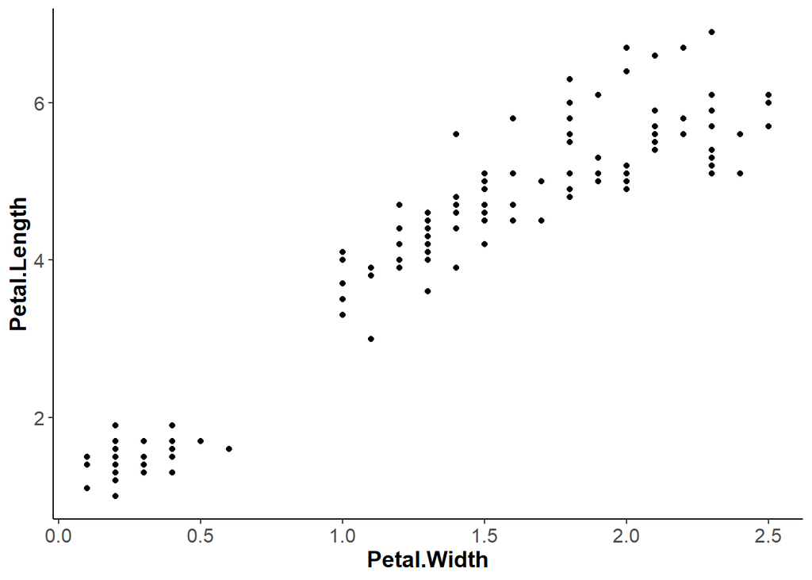

**`theme_minimal()`**

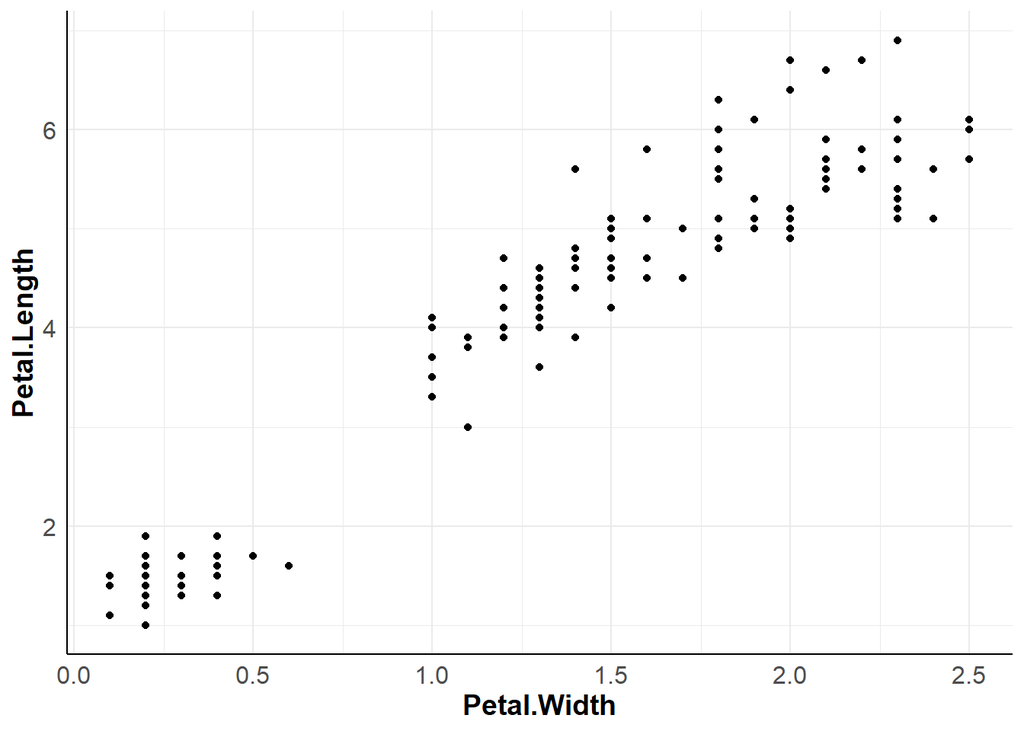

### 6.1.4 Stats in `ggplots`

`ggpubr` is the golden standard package for adding statistical tests to `ggplots`. It can do **a lot** but `stat_compare_means()` is the standard function to use for parametric and non-parametric tests of difference.

Example of how it can be used:

```r
CO2 %>%
    slice(1,2,3,43,44)
```

```
#> Grouped Data: uptake ~ conc | Plant
#>   Plant        Type  Treatment conc uptake
#> 1   Qn1      Quebec nonchilled   95   16.0
#> 2   Qn1      Quebec nonchilled  175   30.4
#> 3   Qn1      Quebec nonchilled  250   34.8
#> 4   Mn1 Mississippi nonchilled   95   10.6
#> 5   Mn1 Mississippi nonchilled  175   19.2
```

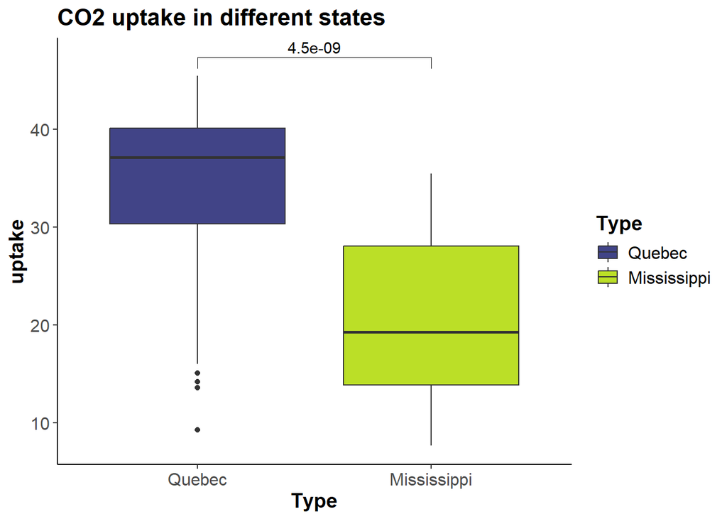

```r
ggplot(data = CO2,aes(x = Type, y = uptake))+
    geom_boxplot(aes(fill = Type))+
    scale_fill_viridis_d(begin = 0.2, end = 0.9)+
    theme_classic()+
    stat_compare_means(method = "t.test",
                       paired = FALSE,
                       comparisons = list(c("Quebec","Mississippi")))+
    labs(title = "CO2 uptake in different states")+
    th
```

## 6.2 Saving `ggplots`

Saving ggplots is quite easy. `ggsave()` is the function to use generally it works like this:

```r
#Create the plot
gg <- ggplot()

ggsave(filename = "gg.pdf", #File name
       plot = gg, #plot object
       path = "C:/Users/chris/OneDrive/1PhD/R_workshop_AUH/R_workshop/plots/", #path to plot file destinaiton
       dpi = 300, #resolution
       width = 2500, #How wide is the plot
       height = 2500, #How tall is the plot
       units = "px", #What is the unit of width and height px = pixels
       device = "pdf") #file type
```

I often save my plots as `.pdf` because I can get very high resolution and maintain small file sizes (they save quickly). But otherwise I save as `.png` (but lower resolution).

## 6.3 `ggplot` tasks

1. Create a function (`gg_func_1()`) that creates a boxplot of `mpg` for each manufacturer in the `mtcars_mod_sele` data set *HINT: Use geom_boxplot()* Save the plot in `R_workshop/plots/` as `gg_1.pdf` from `workshop_plots.R`

**Solution:**

```r
gg_func_1 <- function(data = mtcars_mod_sele){
    gg <- ggplot(data,aes(x = manufacturer,y = mpg))+
        geom_boxplot()+
        theme_classic()+
        th
    return(gg)
}
gg_1 <- gg_func_1()

ggsave(filename = "gg_1.pdf",
       plot = gg_1,
       path = "C:/Users/chris/OneDrive/1PhD/R_workshop_AUH/R_workshop/plots/",
       dpi = 300,
       width = 2500,
       height = 2500,
       units = "px",
       device = "pdf")
```

2. Create a function (`gg_func_2()`) that creates a boxplot of `mpg` for each manufacturer in the `mtcars_mod_sele` data set but also plots the individual values as jittered points and each box is colored according to the manufacturer *HINT: Use geom_boxplot(outlier.alpha = 0), geom_jitter(), aes(fill = manufacturer)* Save the plot in `R_workshop/plots/` as `gg_2.pdf` from `workshop_plots.R`

**Solution:**

```r
gg_func_2 <- function(data = mtcars_mod_sele){
    gg <- ggplot(data,aes(x = manufacturer,y = mpg))+
        geom_boxplot(aes(fill = manufacturer),
                     outlier.alpha = 0)+
        geom_jitter(width = 0.3)+
        scale_fill_viridis_d(begin = 0.2, end = 0.9)+
        theme_classic()+
        th
    return(gg)
}
gg_2 <- gg_func_2()

ggsave(filename = "gg_2.pdf",
       plot = gg_2,
       path = "C:/Users/chris/OneDrive/1PhD/R_workshop_AUH/R_workshop/plots/",
       dpi = 300,
       width = 2500,
       height = 2500,
       units = "px",
       device = "pdf")
```

3. Create a function (`gg_func_3()`) that creates a x/y plot of `Petal.Width` and `Petal.Length` in the `iris` data set. *Hint use geom_point()*. Save the plot in `R_workshop/plots/` as `gg_3.pdf` from `workshop_plots.R`

**Solution:**

```r
gg_func_3 <- function(data = iris){
    gg <- ggplot(data = data,
                 aes(x = Petal.Width,
                     y = Petal.Length))+
        geom_point()+
        theme_classic()+
        th
    return(gg)
}

gg_3 <- gg_func_3()

ggsave(filename = "gg_3.pdf",
       plot = gg_3,
       path = "C:/Users/chris/OneDrive/1PhD/R_workshop_AUH/R_workshop/plots/",
       dpi = 300,
       width = 2500,
       height = 2500,
       units = "px",
       device = "pdf")
```

4. Create a function (`gg_func_4()`) based on `gg_func_3()` that creates a x/y plot of `Petal.Width`and `Petal.Length` in the `iris` data set. But include an additional argument (`species`) where if it is used it only plots for the values for that specific species. *Hint first filter the data set if species is not NULL (use is.null()) and* *species = NULL inside function()*. Save the plots for different species in `R_workshop/plots/` as `gg_4_<species>.pdf` from `workshop_plots.R`

**Solution:**

```r
gg_func_4 <- function(data = iris, species = NULL){
    if(!is.null(species)){
        data <- data %>%
            filter(Species == species)
    }
    gg <- ggplot(data = data,
                 aes(x = Petal.Width,
                     y = Petal.Length))+
        geom_point()+
        theme_classic()+
        th
    return(gg)
}
gg_4_vir <- gg_func_4(species = "virginica")
gg_4_ver <- gg_func_4(species = "versicolor")

ggsave(filename = "gg_4_virginica.pdf",
       plot = gg_4_vir,
       path = "C:/Users/chris/OneDrive/1PhD/R_workshop_AUH/R_workshop/plots/",
       dpi = 300,
       width = 2500,
       height = 2500,
       units = "px",
       device = "pdf")
ggsave(filename = "gg_4_versicolor.pdf",
       plot = gg_4_ver,
       path = "C:/Users/chris/OneDrive/1PhD/R_workshop_AUH/R_workshop/plots/",
       dpi = 300,
       width = 2500,
       height = 2500,
       units = "px",
       device = "pdf")
```

5. Create a function (`gg_func_5()`) based on `gg_func_4()` but the plot needs to include the `species` in the title of the plot or if `specis = NULL` another title has to be included. Also the correlation needs to be added to the plot. *Hint use if(){}else{} to define a label to be used inside* *ggplot()+labs(title = )* *and stat_cor()* Save the plots for different species in `R_workshop/plots/` as `gg_5_<species>.pdf` from `workshop_plots.R`

**Solution:**

```r
gg_func_5 <- function(data = iris, species = NULL){
    if(!is.null(species)){
        data <- data %>%
            filter(Species == species)
        lab = species
    } else{
        lab = "All species"
    }
    gg <- ggplot(data = data,
                 aes(x = Petal.Width,
                     y = Petal.Length))+
        geom_point()+
        theme_classic()+
        labs(title = lab)+
        stat_cor()+
        th
    return(gg)
}
gg_5_vir <- gg_func_5(species = "virginica")
gg_5_ver <- gg_func_5(species = "versicolor")
gg_5_all <- gg_func_5()

ggsave(filename = "gg_5_virginica.pdf",
       plot = gg_5_vir,
       path = "C:/Users/chris/OneDrive/1PhD/R_workshop_AUH/R_workshop/plots/",
       dpi = 300,
       width = 2500,
       height = 2500,
       units = "px",
       device = "pdf")
ggsave(filename = "gg_5_versicolor.pdf",
       plot = gg_5_ver,
       path = "C:/Users/chris/OneDrive/1PhD/R_workshop_AUH/R_workshop/plots/",
       dpi = 300,
       width = 2500,
       height = 2500,
       units = "px",
       device = "pdf")
ggsave(filename = "gg_5_all.pdf",
       plot = gg_5_all,
       path = "C:/Users/chris/OneDrive/1PhD/R_workshop_AUH/R_workshop/plots/",
       dpi = 300,
       width = 2500,
       height = 2500,
       units = "px",
       device = "pdf")
```

6. Create a function (`gg_func_6()`) which compares the Petal.Length between the species. You can choose the `geom` you want. *Hint use stat_compare_means(comparisons = list(c(‘species_1’,‘species_2’)))* Save the plot in `R_workshop/plots/` as `gg_6.pdf` from `workshop_plots.R`

**Solution:**

```r
gg_func_6_a <- function(data = iris){
    comparisons <- combn(as.character(unique(iris$Species)), 2, simplify = FALSE)
    gg <- ggplot(data,aes(x = Species,y = Petal.Length))+
        geom_boxplot(aes(fill = Species),
                     outlier.alpha = 0)+
        geom_jitter(width = 0.3)+
        theme_classic()+
        scale_fill_viridis_d(begin = 0.2,end = 0.9)+
        stat_compare_means(method = "t.test",
                           comparisons = comparisons)+
        th
    return(gg)
}
gg_6_a <- gg_func_6_a()
ggsave(filename = "gg_6_a.pdf",
       plot = gg_6_a,
       path = "C:/Users/chris/OneDrive/1PhD/R_workshop_AUH/R_workshop/plots/",
       dpi = 300,
       width = 2500,
       height = 2500,
       units = "px",
       device = "pdf")

gg_func_6_b <- function(data = iris){
    comparisons <- combn(as.character(unique(iris$Species)), 2, simplify = FALSE)
    gg <- ggplot(data,aes(x = Species,y = Petal.Length))+
        geom_violin(aes(fill = Species))+
        theme_classic()+
        scale_fill_viridis_d(begin = 0.2,end = 0.9)+
        stat_compare_means(method = "t.test",
                           comparisons = comparisons)+
        th
    return(gg)
}
gg_6_b <- gg_func_6_b()
ggsave(filename = "gg_6_b.pdf",
       plot = gg_6_b,
       path = "C:/Users/chris/OneDrive/1PhD/R_workshop_AUH/R_workshop/plots/",
       dpi = 300,
       width = 2500,
       height = 2500,
       units = "px",
       device = "pdf")

gg_func_6_c <- function(data = iris){
    comparisons <- combn(as.character(unique(iris$Species)), 2, simplify = FALSE)
    gg <- ggplot(data,aes(x = Species,y = Petal.Length))+
        geom_bar(aes(fill = Species),
                 stat = "summary")+
        geom_point()+
        coord_flip()+
        theme_classic()+
        scale_fill_viridis_d(begin = 0.2,end = 0.9)+
        stat_compare_means(method = "t.test",
                           comparisons = comparisons)+
        th
    return(gg)
}
gg_6_c <- gg_func_6_c()
ggsave(filename = "gg_6_c.pdf",
       plot = gg_6_c,
       path = "C:/Users/chris/OneDrive/1PhD/R_workshop_AUH/R_workshop/plots/",
       dpi = 300,
       width = 2500,
       height = 2500,
       units = "px",
       device = "pdf")
```

# 7 Happy coding :D

[figure not shown]

Fig 7

# 8 Session info